# Final Project: R Reference

### data.frame()

The data.frame() function is used to construct a data frame.A data frame can contain combination of different vectors, matrices, and arguments.

- A data frame can contain different types of data such as numerical, logical, and character data.
- The columns in a data frame each contain one value from the variables and each row contains one set of values from each columns.
- All elements in a column have the same data type but different columns can have different data types.

```r
## Using the data.frame function to join two vectors into a new data frame

my_vec = rep(1:3, 5)

my_bool_vec<-my_vec == 3

data.frame(my_vec, my_bool_vec)
```

```
##    my_vec my_bool_vec
## 1       1       FALSE
## 2       2       FALSE
## 3       3        TRUE
## 4       1       FALSE
## 5       2       FALSE
## 6       3        TRUE
## 7       1       FALSE
## 8       2       FALSE
## 9       3        TRUE
## 10      1       FALSE
## 11      2       FALSE
## 12      3        TRUE
## 13      1       FALSE
## 14      2       FALSE
## 15      3        TRUE
```

### Functions used with data.frame() and matrix()

nrow() * The nrow() returns the number of rows of a data frame or a matrix.

ncol() * The ncol() returns the number of columns of a data frame or a matrix.

dim() * The dim() function returns or assigns the number of rows and colums of a data frame or a matrix.

```r
## Using the gingko data frame to create examples of nrow(), ncol(), and dim()

gingko = read.csv(here("data", "ginkgo_data_2021.csv"))

nrow(gingko)
```

```
## [1] 756
```

```r
ncol(gingko)
```

```
## [1] 6
```

```r
dim(gingko)
```

```
## [1] 756   6
```

## Subsetting

subsetting with the Gingko data frame with $ gingko$max_width

## Numerical Data Exploration

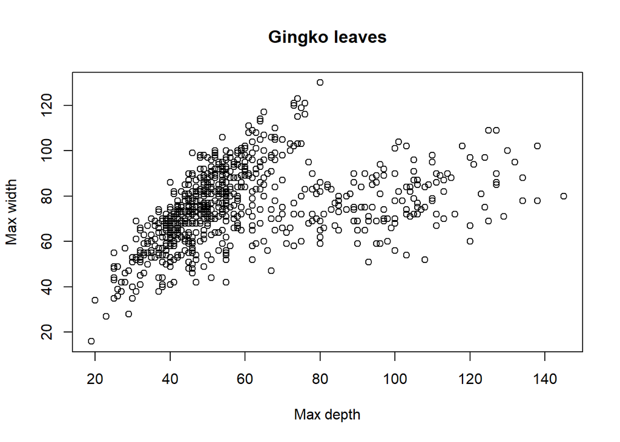

```r
plot(x = gingko$max_depth, y = gingko$max_width,
     xlab = "Max depth", ylab = "Max width", main = "Gingko leaves")
```

```r
require(palmerpenguins)
require(here)

penguins = data.frame(penguins)

penguins
```

[output not shown]

[output cut: 675 more lines]